# MedStat Region Selection

Tino Schneidewind

2024-09-22

### determination of catchments of foehn for hospitalization data

Selected stations: Davos, Chur, Altdorf, Montana, Visp, Magadino, Lugano, Poschiavo. Basis of the selection process of the stations: more than 400 h foehn annually. Around these stations there is a buffer. Every MedStat region that intersects with the Buffer of a station is part of the catchment area for this station.

In my opinion, **the buffer should be as small as possible, because foehn can appear very localized. With a buffer that is too large, our signal from foehn (if there is one) is diluted from areas that are not affected by foehn. If our area is too small, it is possible that we do not have enough hospitalization data to observe a significant trend.**

This is visible in the figure below, as eg **Sion (151 h) and Sierre (542 h) experience very different foehn hours even though they are very close** and part of the same valley.

**I would rather detect mere non signifincant tendencies than the absence of a trend due to the inclusion of to much non relevant data.**

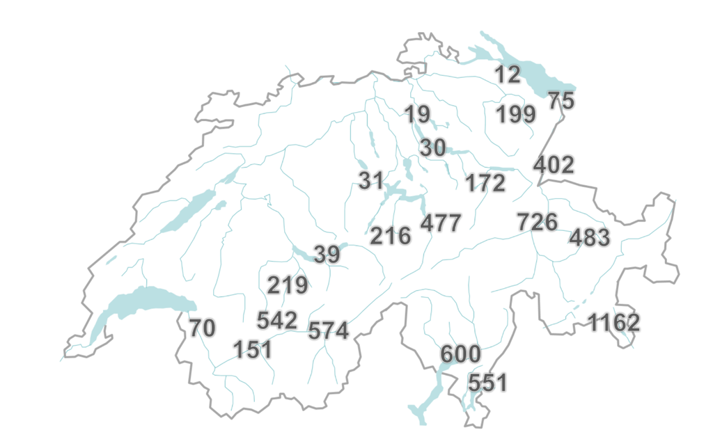

```r
# load data
mesh <- st_read("C:/Users/tinos/Documents/Master - Climate Science/3 - Master Thesis/master_thesis/data-raw/MedStat/MEDSTAT_AREAS_2019.shp", quiet = TRUE)

# transform meshdat geometry to MeteoSchweiz geometry
mesh$geometry <- st_transform(mesh$geometry, crs= 2056)

# create data frame with Station coordinates (from MeteoSchweiz website)
df_stations <- data.frame(station = c("Davos", "Chur", "Altdorf", "Montana", "Visp", "Magadino", "Lugano", "Poschiavo"),
                              x = c("2783519", "2759489", "2690181", "2601709", "2631151", "2715480", "2717874", "2801994"),
                              y = c("1187459", "1193182", "1193564", "1127489", "1128024", "1113161", "1095883", "1136249"),
                              MDSTID = c("GR06200", "GR06001", "UR03002", "VS09802", "VS09605", "TI08001", "TI08204", "GR06804")) # manually searched for in mesh dataset
```

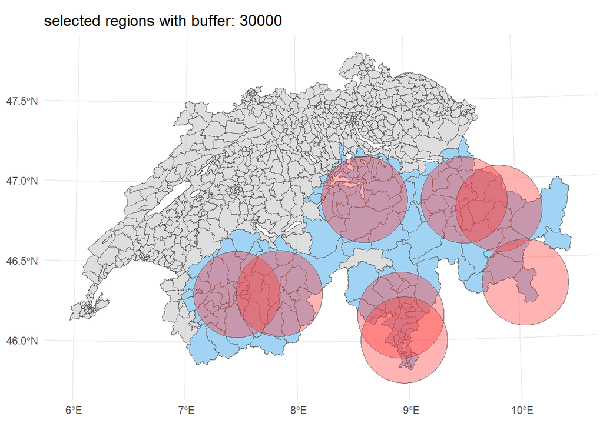

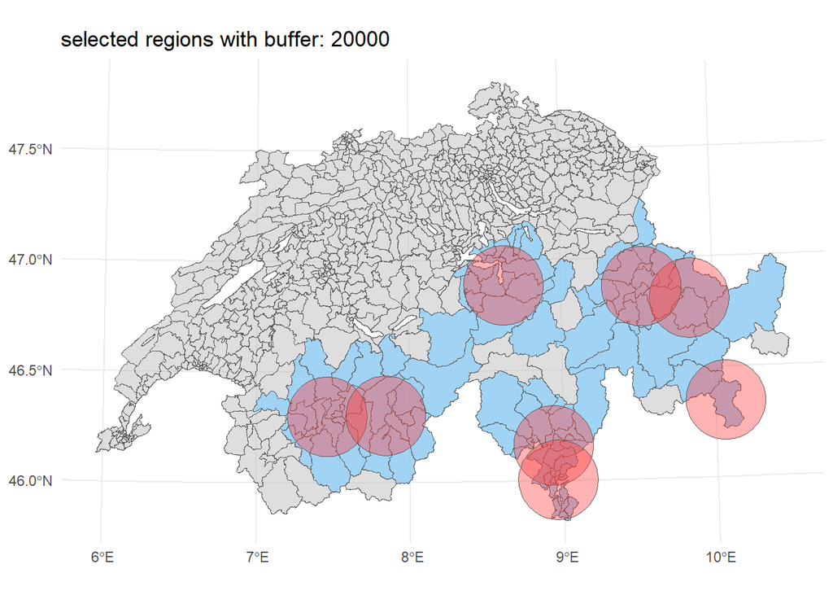

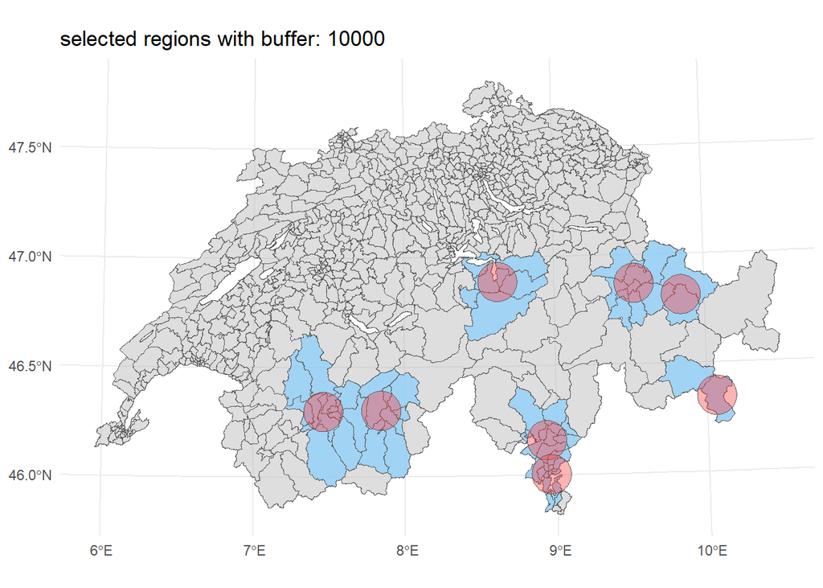

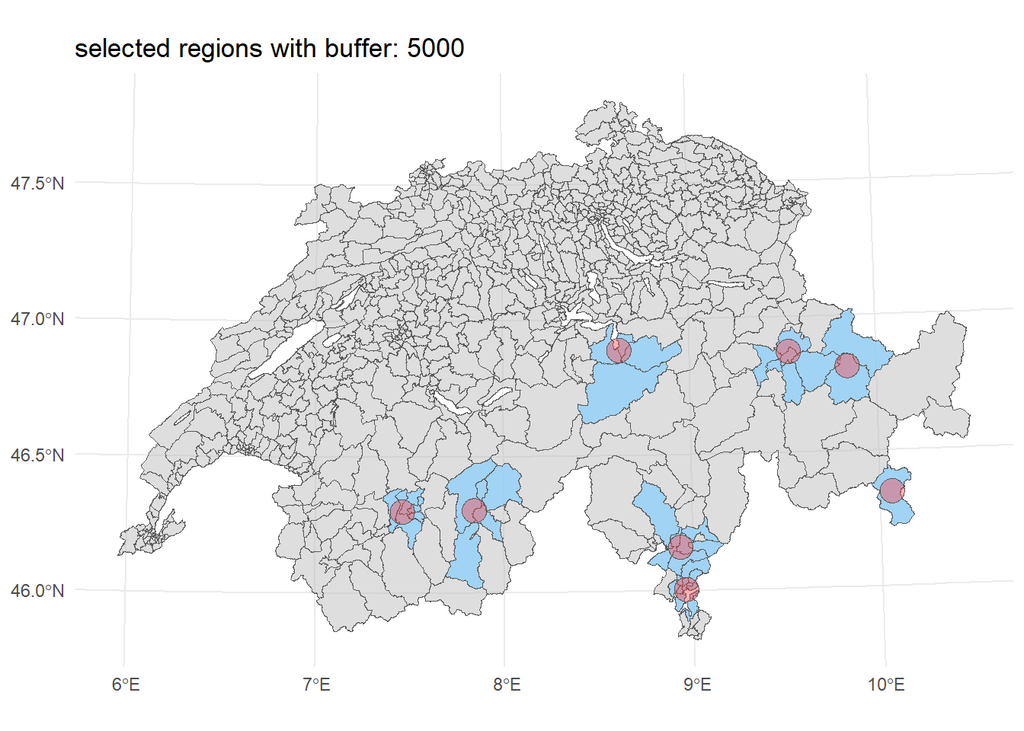

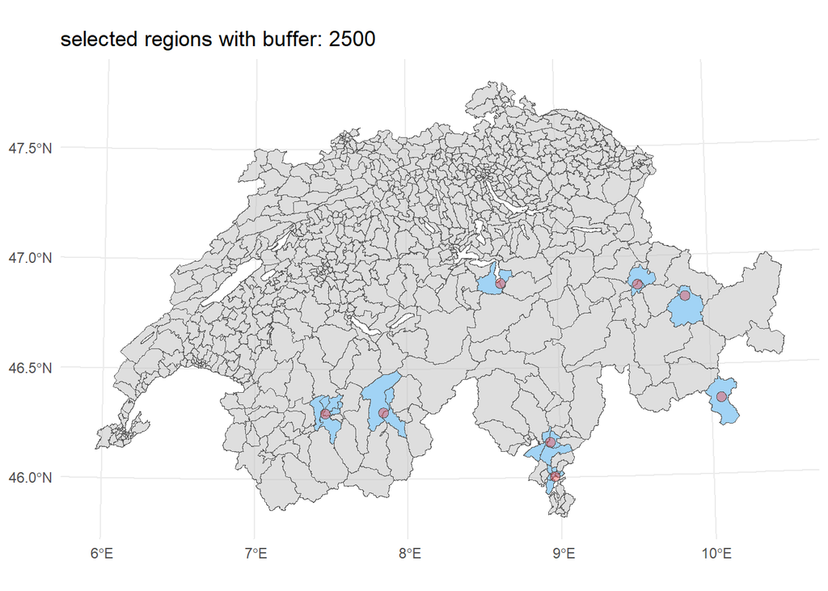

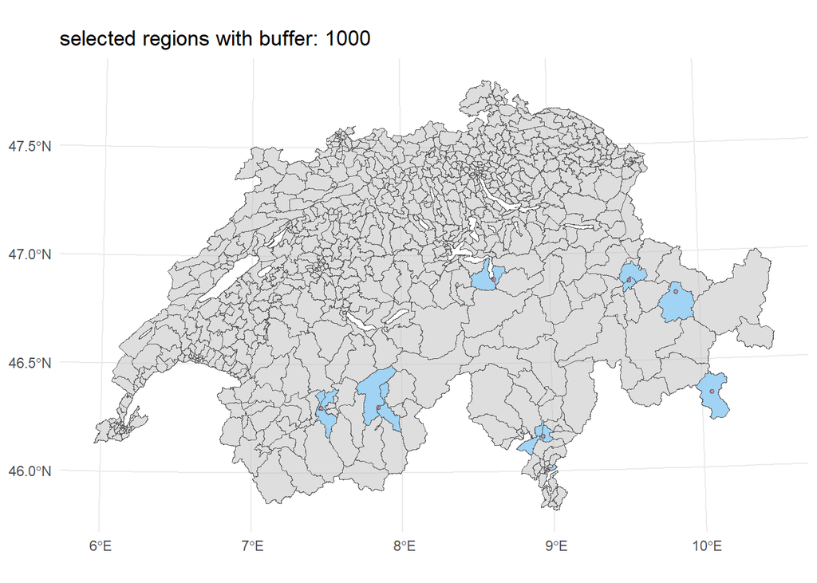

```r
# buffer size 30k
buffer_size = 30000

# list of Meshdat regions that are set to FALSE -> TRUE when they intersect with a buffer
df_regions <- data.frame(MDST04= mesh$MDST04, Index = rep(0, length(mesh$MDSTID)))

# empty list to save buffers in
buffer_list = list()

# calculate the buffer around the 8 stations
for (i in 1:8) {

 # change format of station coordinates into sf as a point
 point_sf <- st_as_sf(df_stations[i,2:3], coords = c("x", "y"), crs = 2056)

 # Create the buffer
 buffer <- st_buffer(point_sf, dist = buffer_size)
 # save buffer
buffer_list[[i]] = buffer

 # Find regions that intersect with the buffer
 intersects_with_buffer <- st_intersects(mesh$geometry, buffer, sparse = FALSE)

 # Add selected regions to regions list
 df_regions$Index <- df_regions$Index +  intersects_with_buffer
}



# Extract all regions that intersect in a list
df_regions$ID <- rep(NA, nrow(mesh))

# for every area that at least intersects once
for(i in 1:length(df_regions$MDST04)){
  if(df_regions$Index[i] > 0){

    # save the area code once again, all others NA
    df_regions$ID[i] <- df_regions$MDST04[i]
  }
}


# create a list for Sujung
list_regions <- na.omit(df_regions$ID)
write.csv(list_regions, file = paste0("C:/Users/tinos/Documents/Master - Climate Science/3 - Master Thesis/master_thesis/data/MetStatRegions/MDSTID_MetRegions_", buffer_size, ".csv"))
```

In the following map, I used the buffer radius 10 km. In my opinion this is too much, because multiple MedStat regions will be included in the analysis that are not relevant as they will rarely experience foehn when there is foehn at the station. Therefore I will start my analysis with 5 km radius buffer. The green marked region was sorted to Chur although it also intersects with the Davos buffer, because the habitable area of this region is better connected to Chur by bigger roads and Chur has more inhabitants, leading to a higher probability of a better healthcare system than Davos.

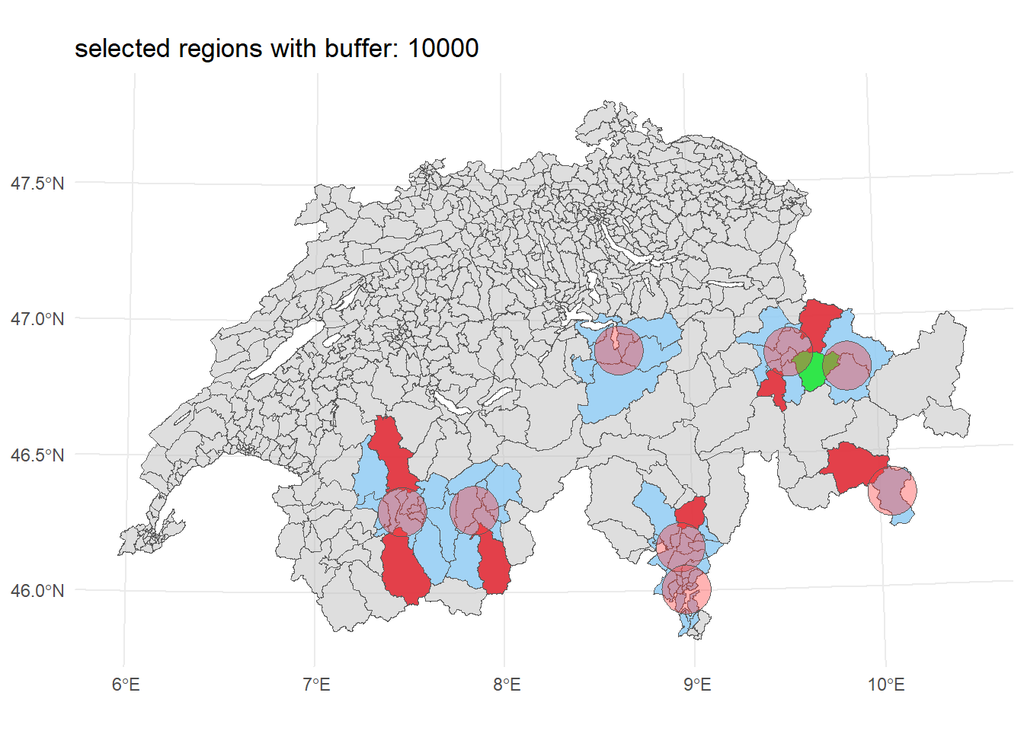